# Workshop 3: From Biological Data to Meaningful Visualizations

Communicating Scientific Evidence with R

Imelda L. Forteza, PhD | BSP–MMSU Workshop Series

August 6,2026

Workshop 3

From Biological Data to Meaningful Visualizations

Communicating Scientific Evidence with R

*A figure is not decoration. It is scientific evidence.*

**Duration**  
Approximately 2 hours

**Approach**  
Guided figure interpretation, critique, and refinement

**Main habit**  
Ask what the reader should see before choosing a plot or test.

Workshop 1

**Organize**  
Files, projects, metadata, and reproducible structure

Workshop 2

**Evaluate**  
Quality, variation, design, and preliminary assessment

Workshop 3

**Communicate**  
Figures, evidence, and biological interpretation

# Welcome MMSU 😊

Imagine that you have completed months of fieldwork, laboratory experiments, and data analysis. A colleague asks a simple question:

> **Can you show me your results?**

Most researchers will not begin with a spreadsheet or a page of statistical output. They will show a figure.

That figure becomes a visual summary of the study. It may be the first evidence a reader examines and, in many cases, the part of the work they remember most clearly.

**Opening discussion**  
What makes a scientific figure convincing? Think of figures you have seen in theses, journal articles, conference talks, or technical reports.

Typical answers include clarity, informative labels, visible observations, appropriate scales, restrained colours, and a conclusion that does not overreach the data.

Biological question → Visualization → Pattern → Statistical support → Biological interpretation

**Guiding principle**  
A good figure does not replace statistics, and statistics do not replace a good figure. They work together to communicate evidence.

## Learning outcomes

By the end of the workshop, participants should be able to:

1. identify the biological question a figure is intended to answer;
2. choose a visualization that matches the structure of the data;
3. distinguish raw observations from summaries;
4. recognize misleading visual choices;
5. interpret treatment comparisons, time-course patterns, community composition, and ordination cautiously;
6. connect a visible pattern to an appropriate statistical question;
7. improve labels, scales, facets, legends, and captions;
8. export a publication-ready figure from R.

# How to use this companion

This is not a live-coding workshop. The figures are generated from the accompanying datasets, and the code is available under the collapsible **Code** buttons for transparency and later reuse.

For every figure, we will ask three questions:

**Three questions for every figure**  
1. What biological question does this figure answer?  
2. What pattern should the reader notice?  
3. What conclusion would be inappropriate from this figure alone?

## Required packages

```r
cran_packages <- c(
  "tidyverse",
  "janitor",
  "vegan",
  "scales"
)
bioc_packages <- c("phyloseq")

missing_cran <- cran_packages[
  !vapply(cran_packages, requireNamespace, logical(1), quietly = TRUE)
]
missing_bioc <- bioc_packages[
  !vapply(bioc_packages, requireNamespace, logical(1), quietly = TRUE)
]

if (length(missing_cran) > 0) {
  install.packages(missing_cran)
}

if (length(missing_bioc) > 0) {
  if (!requireNamespace("BiocManager", quietly = TRUE))
    install.packages("BiocManager")
  BiocManager::install(missing_bioc, update = FALSE)
}

library(tidyverse)
library(janitor)
library(phyloseq)
library(vegan)
library(scales)
```

# Part 1 — Choose the figure from the question

A plot is useful only when it makes the intended comparison visible.

| Biological question | Useful starting figure | What it should reveal |
| --- | --- | --- |
| How are values distributed? | Histogram or density plot | Shape, skewness, gaps, and unusual values |
| Do groups differ? | Raw points with boxplot or interval | Sample size, spread, overlap, and group location |
| Does a response change over time? | Points and lines or summaries over time | Direction, timing, and variation |
| Are two continuous variables related? | Scatterplot | Direction, form, spread, and unusual observations |
| Which taxa dominate a community? | Stacked composition plot or heatmap | Relative composition and dominant groups |
| Are communities similar or different? | Ordination | Between-sample relationships in reduced dimensions |

**Common mistake**  
Do not begin with the plotting function you remember. Begin with the biological comparison the reader needs to make.

## Figure critique: a mean is not the whole dataset

A bar showing only a group mean hides the number of observations, spread, skewness, overlap, and unusual values.

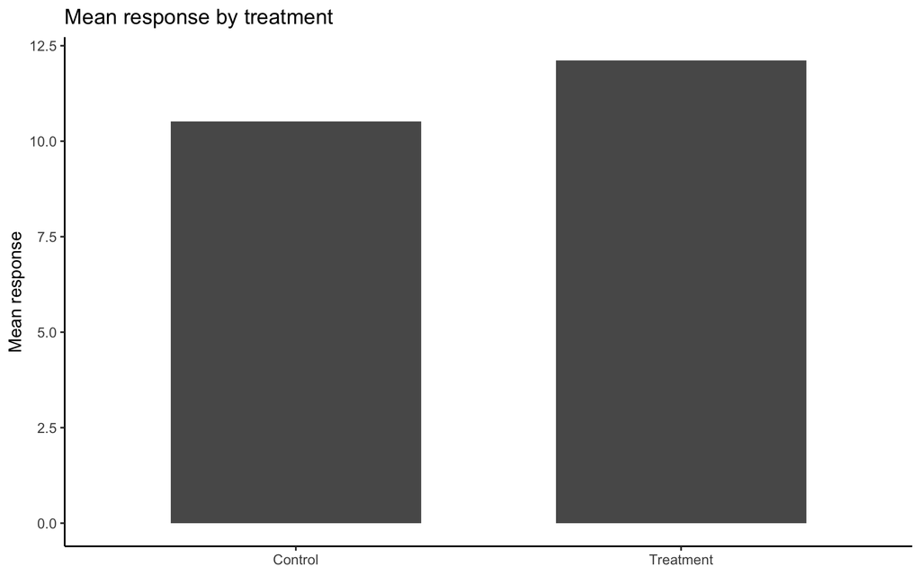

**Think like a reviewer**  
How many observations produced each bar? Do the groups overlap? Are there unusual values? The figure does not allow us to answer.

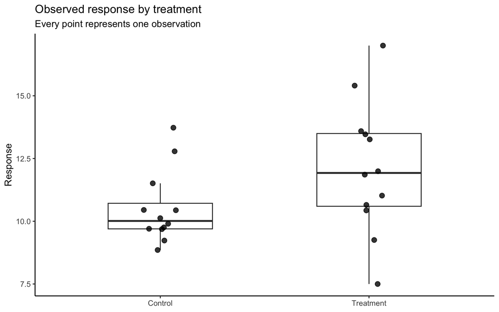

**Interpretation**  
The second figure reveals sample size, spread, overlap, and two observations that strongly influence the treatment distribution. It provides evidence that the bar chart concealed.

# Part 2 — Case Study 1: BALO-associated kinetics

The first dataset contains measurements from a predator–prey experiment. Variables include time, host, treatment, measurement type, and observed value.

## Import and inspect

```r
balo <- read_csv(
  "BALO_PHAGE_Kinetics_OD_CFU_PFU.csv",
  show_col_types = FALSE
) |>
  clean_names() |>
  mutate(
    host = factor(host),
    type = factor(type),
    treatment = factor(treatment),
    metric = factor(metric),
    time_hr = as.numeric(time_hr),
    value = as.numeric(value),
    value_clean = as.numeric(value_clean)
  )

glimpse(balo)
```

```
## Rows: 1,694
## Columns: 8
## $ time_hr     <dbl> 0, 0, 0, 0, 0, 0, 0, 0, 0, 0, 0, 0, 0, 0, 0, 0, 0, 0, 0, 0…
## $ host        <fct> BALO, BALO, BALO, BALO, BALO, BALO, BALO, BALO, BALO, Phag…
## $ type        <fct> 1M, 1M, 1M, 1M, 1M, 1M, 1M, 1M, 1M, 1M, 1M, 1M, 1M, 1M, 1M…
## $ treatment   <fct> 1M_BALO, 1M_BALO, 1M_BALO, 1M_BALO, 1M_BALO, 1M_BALO, 1M_B…
## $ description <chr> "BALO", "BALO", "BALO", "BALO", "BALO", "BALO", "BALO", "B…
## $ metric      <fct> PFU, PFU, PFU, PFU, PFU, PFU, PFU, PFU, PFU, PFU, PFU, PFU…
## $ value       <dbl> 35, 27, 32, 21, 30, 30, 28, 26, 20, 367, 376, 278, 23, 314…
## $ value_clean <dbl> 35, 27, 32, 21, 30, 30, 28, 26, 20, 367, 376, 278, 23, 314…
```

**Important data limitation**  
The file does not contain an explicit replicate identifier. We therefore cannot reliably connect rows as individual replicate trajectories. Lines must not imply repeated measurements from the same experimental unit unless that identity is known.

## What measurements are present?

Number of observations available for each metric, host, and treatment.

| metric | host | treatment | observations |
| --- | --- | --- | --- |
| CFU | A.sobria | 1M_A | 45 |
| CFU | A.sobria | 2M | 90 |
| CFU | A.sobria | 3M | 45 |
| CFU | E.coli | 1M_E | 36 |
| CFU | E.coli | 2M | 72 |
| CFU | E.coli | 3M | 36 |
| OD | A.sobria | 1M_A | 45 |
| OD | A.sobria | 2M | 90 |
| OD | A.sobria | 3M | 45 |
| OD | BALO | 1M | 9 |
| OD | BALO | 1M_BALO | 81 |
| OD | BALO | 2M | 100 |
| OD | E.coli | 1M_E | 45 |
| OD | E.coli | 2M | 90 |
| OD | E.coli | 3M | 45 |
| OD | Phage | 1M_Phage | 90 |
| PFU | A.sobria | 2M | 90 |
| PFU | A.sobria | 3M | 90 |
| PFU | BALO | 1M_BALO | 89 |
| PFU | BALO | 2M | 190 |
| PFU | E.coli | 2M | 90 |
| PFU | E.coli | 3M | 90 |
| PFU | Phage | 1M_BALO | 1 |
| PFU | Phage | 1M_Phage | 90 |

**Biological question**  
How do PFU measurements change across incubation time, host, and treatment?

## First view: show the observations

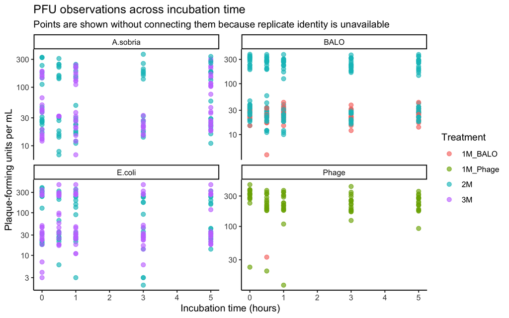

**Figure focus**  
The log scale allows measurements spanning several orders of magnitude to remain visible. Facets prevent hosts with very different ranges from obscuring one another.

**What this figure does not show**  
It does not show individual biological trajectories. It also does not establish that treatment caused the visible differences.

## Add a summary

Because replicate identity is missing, we can summarize observations at each time point without pretending that points belong to known individual trajectories.

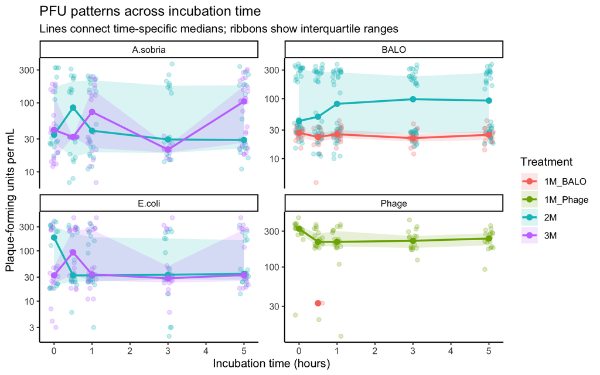

**Interpretation prompt**  
Which treatment–host combinations show a consistent increase, decrease, or irregular pattern? How much overlap is visible? Which panels have limited observations?

**Reviewer 2 asks**  
What is the independent biological unit? Were the same cultures measured repeatedly? Without replicate identifiers, the figure is descriptive and repeated-measures inference cannot be reconstructed confidently.

## Compare multiple metrics without forcing one scale

OD, CFU, and PFU have different units and ranges. Plotting them on one shared axis would be misleading.

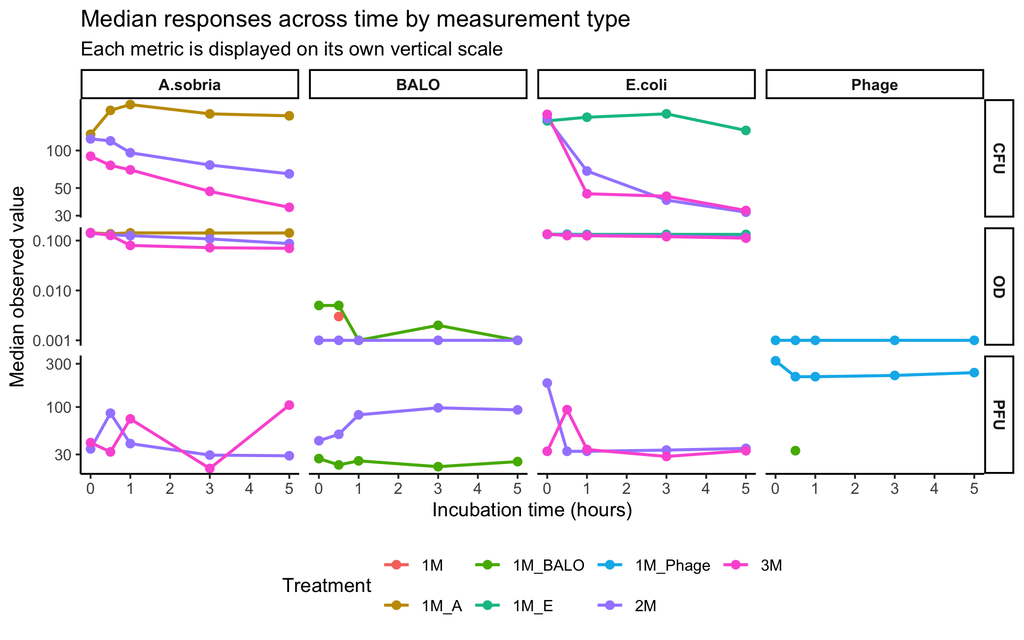

**Why facet by metric?**  
OD, CFU, and PFU do not measure the same biological quantity. Separate panels preserve their units and prevent a large-valued metric from flattening the others.

## Statistics should answer the visible question

A statistical test should not be added simply because a figure exists. First specify the comparison.

For example:

> At one biologically justified endpoint, do PFU distributions differ among treatments for one host?

The code below demonstrates the logic at the latest available time for a selected host. It is intentionally framed as an example, not as a universal analysis.

```r
selected_host <- levels(droplevels(balo_pfu$host))[1]

endpoint_data <- balo_pfu |>
  filter(host == selected_host) |>
  filter(time_hr == max(time_hr, na.rm = TRUE)) |>
  droplevels()

endpoint_data |>
  count(treatment, name = "n")
```

```
## # A tibble: 2 × 2
##   treatment     n
##   <fct>     <int>
## 1 2M           18
## 2 3M           27
```

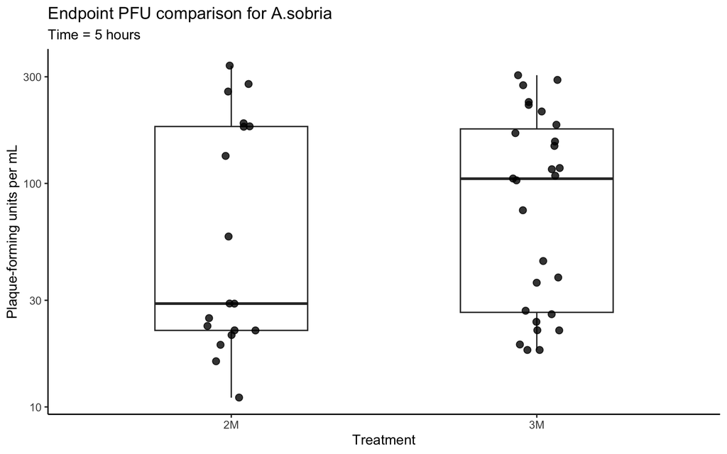

```r
if (n_distinct(endpoint_data$treatment) >= 2) {
  kruskal.test(value_clean ~ treatment, data = endpoint_data)
}
```

```
##
##  Kruskal-Wallis rank sum test
##
## data:  value_clean by treatment
## Kruskal-Wallis chi-squared = 0.75548, df = 1, p-value = 0.3847
```

**Connected interpretation**  
The test addresses only the selected host and endpoint. It does not evaluate the full time course, repeated measurements, or all host–treatment interactions.

**Mini challenge**  
Choose one BALO panel. Write two sentences: one describing the visible pattern and one stating what cannot be concluded because replicate identity is absent.

# Part 3 — Case Study 2: Soil microbial communities

The molecular dataset combines an abundance table, sample metadata, and taxonomy. Workshop 3 focuses on visualization and interpretation, but the components must still be aligned correctly.

## Import the components

```r
metadata_raw <- read_csv(
  "soil_metadata.csv",
  show_col_types = FALSE
) |>
  clean_names()

otu_raw <- read_csv(
  "soil.otu.csv",
  show_col_types = FALSE
)

tax_raw <- read_csv(
  "soil.tax.csv",
  show_col_types = FALSE
)

dim(metadata_raw)
```

```
## [1] 21  9
```

```r
dim(otu_raw)
```

```
## [1] 15331    21
```

```r
dim(tax_raw)
```

```
## [1] 15713     8
```

## Harmonize sample identifiers transparently

```r
## Identify samples and features shared across files

## OTU sample names
otu_sample_ids <- names(otu_raw)[-1]

length(otu_sample_ids)
```

```
## [1] 20
```

```r
head(otu_sample_ids, 10)
```

```
##  [1] "V92S41260"  "SSLF1563"   "SLS31664"   "SFR2044"    "V57VSLS520"
##  [6] "VSLS52145"  "SSL2246"    "SL529"      "Soil72"     "SOIL72"
```

```r
## Metadata sample names
metadata_sample_ids <- metadata_raw$orig_id

length(metadata_sample_ids)
```

```
## [1] 21
```

```r
head(metadata_sample_ids, 10)
```

```
##  [1] "V92S41260"  "V92S41260"  "SSLF1563"   "SLS31664"   "SFR2044"
##  [6] "V57VSLS520" "VSLS52145"  "SSL2246"    "SL529"      "SLSU856"
```

**Think like a reviewer**  
Identifier harmonization is part of the evidence trail. Document what was changed rather than silently renaming samples.

```r
## Sample identifiers

## OTU sample names
otu_sample_ids <- names(otu_raw)[-1]

length(otu_sample_ids)
```

```
## [1] 20
```

```r
head(otu_sample_ids, 10)
```

```
##  [1] "V92S41260"  "SSLF1563"   "SLS31664"   "SFR2044"    "V57VSLS520"
##  [6] "VSLS52145"  "SSL2246"    "SL529"      "Soil72"     "SOIL72"
```

```r
## Metadata sample names
metadata_sample_ids <- metadata_raw$orig_id

length(metadata_sample_ids)
```

```
## [1] 21
```

```r
head(metadata_sample_ids, 10)
```

```
##  [1] "V92S41260"  "V92S41260"  "SSLF1563"   "SLS31664"   "SFR2044"
##  [6] "V57VSLS520" "VSLS52145"  "SSL2246"    "SL529"      "SLSU856"
```

```r
setdiff(otu_sample_ids, metadata_sample_ids)
```

```
##  [1] "Soil72"      "SOIL72"      "SOIL82"      "S4WOOD"      "SOIL4"
##  [6] "SOIL4FRASS"  "SOILA"       "SOILVELVET"  "SWOODSPIDER" "V88soil"
```

```r
setdiff(metadata_sample_ids, otu_sample_ids)
```

```
##  [1] "820-72Soil"      "820-72SOIL"      "820-82SOIL"      "820-S4WOOD"
##  [5] "820-SOIL4"       "820-SOIL4FRASS"  "820-SOILA"       "820-SOILVELVET"
##  [9] "820-SWOODSPIDER" "820-V88soil"
```

## Build a validated phyloseq object

```r
common_features <- intersect(
  otu_raw$OTUID,
  tax_raw$`Feature ID`
)

  common_samples <- intersect(
    otu_sample_ids,
    metadata_sample_ids
)

length(common_samples)
```

```
## [1] 10
```

```r
otu_mat <- otu_raw |>
  filter(OTUID %in% common_features) |>
  column_to_rownames("OTUID") |>
  select(all_of(common_samples)) |>
  as.matrix()

tax_mat <- tax_raw |>
  filter(`Feature ID` %in% common_features) |>
  column_to_rownames("Feature ID") |>
  select(Kingdom, Phylum, Class, Order, Family, Genus, Species) |>
  as.matrix()

metadata_matched <-
    metadata_raw |>
    filter(orig_id %in% otu_sample_ids) |>
    distinct(orig_id, .keep_all = TRUE) |>
    tibble::column_to_rownames("orig_id")

ps <- phyloseq(
  otu_table(otu_mat, taxa_are_rows = TRUE),
  tax_table(tax_mat),
  sample_data(metadata_matched)
)

ps
```

```
## phyloseq-class experiment-level object
## otu_table()   OTU Table:         [ 15331 taxa and 10 samples ]
## sample_data() Sample Data:       [ 10 samples by 8 sample variables ]
## tax_table()   Taxonomy Table:    [ 15331 taxa by 7 taxonomic ranks ]
```

**Important**  
The phyloseq object is a synchronized data structure. It is not itself a statistical analysis.

# Part 4 — Sequencing depth: what entered the analysis?

**Biological and technical question**  
Do all samples have similar sequencing depth, and are unusually shallow samples associated with a locality, site, or batch?

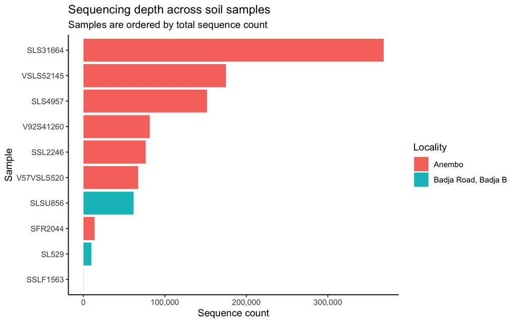

```r
depth_data <- tibble(
  sample_id = sample_names(ps),
  reads = sample_sums(ps)
) |>
  left_join(
    data.frame(sample_data(ps)) |>
      rownames_to_column("sample_id"),
    by = "sample_id"
  )
```

**What should the reader see?**  
The figure should reveal shallow samples, broad differences in depth, and whether low-depth samples cluster within one metadata category.

**Common mistake**  
Do not choose a sequencing-depth threshold only after seeing which samples support the preferred biological result.

# Part 5 — Alpha diversity: variation within samples

Alpha diversity describes diversity within each sample. It does not identify which taxa changed or whether whole-community composition differs.

```r
alpha <- estimate_richness(
  ps,
  measures = c("Observed", "Shannon")
) |>
  rownames_to_column("sample_id") |>
  left_join(
    data.frame(sample_data(ps)) |>
      rownames_to_column("sample_id"),
    by = "sample_id"
  )
```

**Biological question**  
Does within-sample diversity differ among localities?

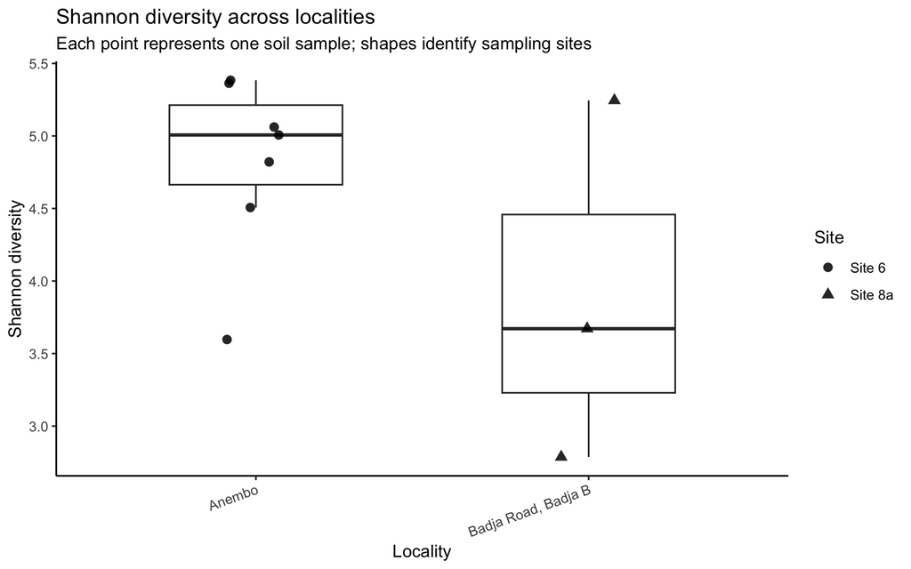

**Interpretation prompt**  
Compare group locations, spread, overlap, sample size, and possible site structure. Avoid stating that one locality is biologically more diverse based only on a small visual difference.

```r
kruskal.test(Shannon ~ locality, data = alpha)
```

```
##
##  Kruskal-Wallis rank sum test
##
## data:  Shannon by locality
## Kruskal-Wallis chi-squared = 1.0519, df = 1, p-value = 0.3051
```

**Reviewer 2 asks**  
Are locality and site independent, nested, or confounded? A simple group test may not reflect the full sampling design.

# Part 6 — Taxonomic composition: what appears to dominate?

Relative-abundance plots communicate composition, not absolute microbial load.

## Aggregate at phylum level

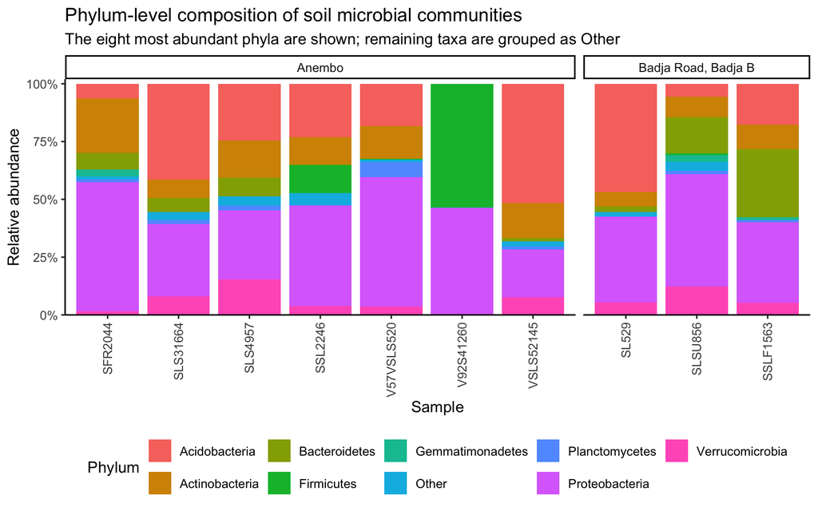

```r
ps_phylum <- tax_glom(
  ps,
  taxrank = "Phylum",
  NArm = FALSE
)

ps_phylum_rel <- transform_sample_counts(
  ps_phylum,
  function(x) x / sum(x)
)

phylum_long <- psmelt(ps_phylum_rel) |>
  as_tibble() |>
  mutate(
    Phylum = replace_na(as.character(Phylum), "Unclassified")
  )

top_phyla <- phylum_long |>
  group_by(Phylum) |>
  summarise(mean_abundance = mean(Abundance), .groups = "drop") |>
  slice_max(mean_abundance, n = 8) |>
  pull(Phylum)

phylum_plot_data <- phylum_long |>
  mutate(
    display_phylum = if_else(
      Phylum %in% top_phyla,
      Phylum,
      "Other"
    )
  ) |>
  group_by(Sample, locality, display_phylum) |>
  summarise(Abundance = sum(Abundance), .groups = "drop")
```

**Interpret cautiously**  
All proportions within a sample sum to one. An increase in one taxon necessarily changes the apparent proportions of others. Relative abundance is not absolute abundance.

**Why group rare taxa as Other?**  
A legend containing dozens of colours does not communicate more information. It shifts attention away from the dominant or biologically relevant groups.

**Mini challenge**  
Choose one sample and describe its dominant phyla without using the words “more microbes” or “fewer microbes.”

# Part 7 — Beta diversity: relationships among communities

Ordination compresses complex between-sample relationships into a small number of axes. It is descriptive and exploratory.

**Biological question**  
Do soil microbial communities from different localities appear more similar within localities than between localities?

## Bray–Curtis ordination

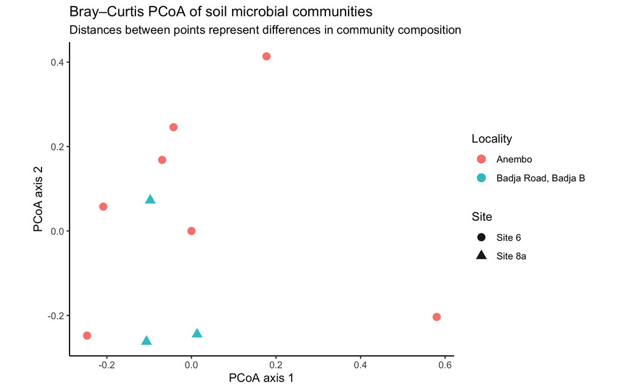

```r
bray <- phyloseq::distance(ps, method = "bray")
ord <- ordinate(ps, method = "PCoA", distance = bray)

ordination_data <- plot_ordination(
  ps,
  ord,
  type = "samples",
  justDF = TRUE
) |>
  as_tibble()
```

**What the ordination can show**  
Samples plotted near one another have more similar community composition under the selected distance measure. Visible separation suggests a pattern worth evaluating.

**What the ordination cannot prove**  
Visual separation alone is not a hypothesis test. Adding ellipses does not make the separation statistically significant.

## Connect the pattern to PERMANOVA

```r
meta <- data.frame(sample_data(ps))
meta <- meta[attr(bray, "Labels"), , drop = FALSE]

permanova <- vegan::adonis2(
  bray ~ locality,
  data = meta,
  permutations = 999
)

permanova
```

```
## Permutation test for adonis under reduced model
## Terms added sequentially (first to last)
## Permutation: free
## Number of permutations: 999
##
## vegan::adonis2(formula = bray ~ locality, data = meta, permutations = 999)
##          Df SumOfSqs      R2  F Pr(>F)
## locality  1      0.5 0.11111  1      1
## Residual  8      4.0 0.88889
## Total     9      4.5 1.00000
```

## Check multivariate dispersion

```r
dispersion <- vegan::betadisper(
  bray,
  group = meta$locality
)

anova(dispersion)
```

```
## Analysis of Variance Table
##
## Response: Distances
##           Df   Sum Sq  Mean Sq  F value    Pr(>F)
## Groups     1 0.012549 0.012549 16148300 < 2.2e-16 ***
## Residuals  8 0.000000 0.000000
## ---
## Signif. codes:  0 '***' 0.001 '**' 0.01 '*' 0.05 '.' 0.1 ' ' 1
```

```r
permutest(dispersion, permutations = 999)
```

```
##
## Permutation test for homogeneity of multivariate dispersions
## Permutation: free
## Number of permutations: 999
##
## Response: Distances
##           Df   Sum Sq  Mean Sq        F N.Perm Pr(>F)
## Groups     1 0.012549 0.012549 16148300    999  0.001 ***
## Residuals  8 0.000000 0.000000
## ---
## Signif. codes:  0 '***' 0.001 '**' 0.01 '*' 0.05 '.' 0.1 ' ' 1
```

**Connected interpretation template**  
Community composition differed / did not differ detectably among localities under PERMANOVA, explaining ___% of the variation. Multivariate dispersion was / was not detectably different among groups. Interpretation remains limited by sample size and sampling structure.

**Reviewer 2 asks**  
Were permutations appropriate for the sampling design? If samples are nested, blocked, paired, or repeatedly measured, unrestricted permutations may be invalid.

# Part 8 — Improve a figure one decision at a time

A publication-ready figure is not created by adding decoration. Each layer should improve comparison, accuracy, or readability.

## A practical refinement checklist

| Decision | Question to ask |
| --- | --- |
| Title | Does it state the scientific content rather than “Graph 1”? |
| Axes | Are the variables and units explicit? |
| Scale | Does a transformation clarify the biology without hiding zeros or detection limits? |
| Points | Are raw observations visible where practical? |
| Lines | Do they connect valid trajectories or clearly identified summaries? |
| Facets | Do panels simplify a complex comparison? |
| Colour | Does colour encode information consistently? |
| Shape | Can groups still be distinguished without colour? |
| Legend | Is every label necessary and understandable? |
| Caption | Can the figure stand alone from the main text? |

## Accessibility

- Do not rely on colour alone.
- Combine colour with shape, line type, or facets.
- Avoid rainbow palettes.
- Keep treatment encodings consistent across figures.
- Use sufficiently large text and symbols.
- Check whether the figure remains understandable in grayscale.
- Avoid crowded legends and excessive decimal precision.

**Design rule**  
Every visual element should carry scientific information or improve readability. Remove elements that do neither.

# Part 9 — Write a stand-alone caption

A figure caption should tell readers:

1. what was measured;
2. which groups, sites, hosts, or times were compared;
3. what each point, line, box, ribbon, or colour represents;
4. whether data were transformed or normalized;
5. which statistical method was used;
6. the relevant sample size or limitation.

## Caption template

> **Figure X.** [Response or biological feature] across [treatments, sites, hosts, or time]. Points represent [independent biological units]. Lines, boxes, ribbons, colours, and shapes indicate [precise visual meanings]. Data were [transformed, normalized, or aggregated] using [method]. Differences were evaluated using [test] where applicable. [Important limitation].

## Example

> **Figure X.** Shannon diversity across soil localities. Each point represents one soil sample; boxes show the median and interquartile range, and shapes identify sampling sites. Group differences were explored using a Kruskal–Wallis test. The figure describes within-sample diversity and does not identify which taxa account for the observed pattern.

**Common mistake**  
Do not write “The graph above shows…” A caption should remain meaningful when the figure is separated from the surrounding text.

# Part 10 — Export figures deliberately

```r
ggsave(
  filename = "figures/balo_pfu_timecourse.png",
  plot = last_plot(),
  width = 8,
  height = 5,
  units = "in",
  dpi = 300
)

ggsave(
  filename = "figures/balo_pfu_timecourse.pdf",
  plot = last_plot(),
  width = 8,
  height = 5,
  units = "in"
)
```

Use:

- **PNG** for slides, web pages, and many reports;
- **PDF** or **SVG** for scalable vector graphics;
- consistent dimensions for related figures;
- meaningful filenames;
- a dedicated `figures/` folder;
- the original R code rather than screenshots from the RStudio plot pane.

# Part 11 — Think like Reviewer 2

Use this checklist before submitting a thesis, report, or manuscript.

**Figure review checklist**  
Does the figure answer a clear biological question?  
Are independent biological observations visible or described?  
Are units and transformations explicit?  
Do lines connect valid trajectories?  
Are colours and symbols interpretable and accessible?  
Does the caption explain every visual element?  
Is the statistical method connected to the displayed comparison?  
Does the interpretation remain within what the design supports?

## Common visualization and interpretation mistakes

1. Showing only means and hiding the observations.
2. Treating technical replicates as biological replication.
3. Connecting points that do not belong to the same trajectory.
4. Applying a log scale without addressing zeros or detection limits.
5. Using one axis for variables with different units.
6. Interpreting relative abundance as absolute microbial quantity.
7. Treating ordination separation as proof of significance.
8. Running PERMANOVA without checking dispersion.
9. Adding significance stars without estimates, uncertainty, or biological context.
10. Using colour as decoration rather than information.
11. Writing captions that cannot stand alone.
12. Claiming causation from an observational or incompletely controlled design.

# Part 12 — Final figure challenge

Choose either the BALO dataset or the soil microbial-community dataset.

Final activity

Complete the following:

1. State one biological question.
2. Identify the independent biological unit—or state why it cannot be recovered.
3. Choose one visualization and justify it.
4. Show the raw observations where appropriate.
5. Improve the labels, scale, facets, and legend.
6. State the visible pattern.
7. Identify the statistical question that follows from the pattern.
8. Write a two- to three-sentence biological interpretation.
9. State one important limitation.
10. Write a stand-alone figure caption.
11. Export the figure using a meaningful filename.

**Final reflection**  
If a reader saw only your figure and caption, would they understand the biological question, the evidence, and the limits of the conclusion?

# Key take-home messages

**The central lesson**  
Good analysis does not begin with a test and end with a significant p-value. It begins with a defensible biological question and ends with a transparent figure, appropriate statistical evidence, and a cautious interpretation.

1. Choose the figure from the biological question.
2. Show observations before reducing them to summaries.
3. Lines, scales, colours, and facets carry scientific meaning.
4. Replication and independence come from the study design.
5. Statistics should evaluate a clearly stated comparison visible in the figure.
6. Relative abundance is compositional, not absolute quantity.
7. Ordination is descriptive; PERMANOVA is inferential; dispersion also matters.
8. A publication-ready figure is clear, accessible, reproducible, and honestly interpreted.
9. Every caption should allow the figure to stand alone.
10. State what the evidence does not establish.

# Instructor notes

- This is a guided interpretation workshop, not a live-coding session.
- Knit the HTML before delivery and confirm that all figures render.
- Use the collapsible code only when participants ask how a figure was produced.
- Emphasize the absence of a replicate identifier in the BALO file as a real example of why metadata matter.
- Do not imply individual BALO trajectories unless a verified replicate column becomes available.
- Keep the endpoint test as an illustration of connecting a figure to a precise question.
- Avoid presenting the alpha-diversity test as a complete model of the sampling design.
- Discuss PERMANOVA only after participants have interpreted the ordination.
- Ask participants to explain what each figure cannot establish.
- Keep the final activity focused on one defensible figure rather than many plots.

**BSP–MMSU Workshop Series**  
Workshop 3 · From Biological Data to Meaningful Visualizations